# Practical Machine Learning - A prediction algorithm for Human Activity Recognition based on quantified hips possition and acceleration (class E)

Antonio Marquez Palacios

March 4, 2018

## Abstract

This document is a course project for the Practical Machine Learning course as part of Coursera Data Science Specialization. Information about the course can be found at https://www.coursera.org/learn/practical-machine-learning/

## Synosis

In this project, a mathematical model for machine learning using Random Forests is proposed to predict how well the exercises are done, based on Class E classification.

## Loading and setting the data

Data for this project can be found

Training data set: https://d396qusza40orc.cloudfront.net/predmachlearn/pml-training.csv Testing data set: https://d396qusza40orc.cloudfront.net/predmachlearn/pml-testing.csv

An initial exploratory analysis reveals some columns have NA/NULL/empty values in their majority observations; also the data is not dependent on time, so will remove them to have a cleaner analysis

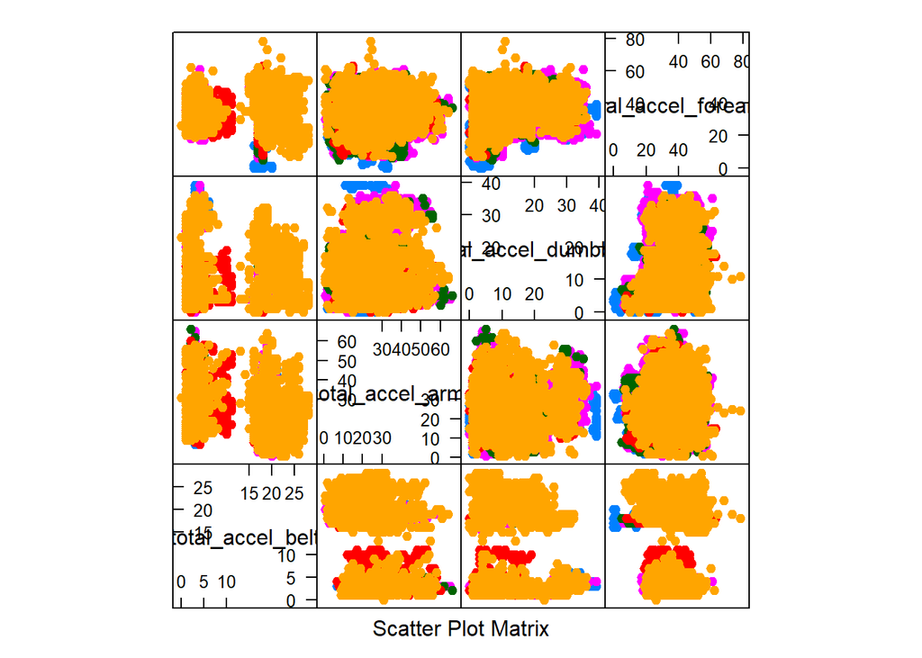

```r
# Load the set Data Set
set.seed(33878)
trainingFilePath  <- "pml-training.csv"
testingFilePath   <- "pml-testing.csv"

pmlTrainDS        <- read.csv(trainingFilePath)
pmlTestDS         <- read.csv(testingFilePath)

validColumns      <- c(2, 6:11, 37:49, 60:68, 84:86, 102, 113:124,140,151:160 )
# Remove those columns that have NA in their majority observations
filteredTrainDS   <- pmlTrainDS[, validColumns]
filteredTestDS    <- pmlTestDS[, validColumns]

# Set a value to be the outcome of the models:
inTrain   <- createDataPartition(filteredTrainDS$classe, p=0.7, list=FALSE)
training  <- filteredTrainDS[inTrain, ]
testing   <- filteredTrainDS[-inTrain,]

totalCol <- which(grepl("^total", names(training), ignore.case=FALSE))

featurePlot(x= training[, totalCol], y=training$classe, pch=19, plot="pairs")
```

## Fitting a Model and Cross Validation

Random Forest is the selected model because of its accuracy. Calculating Random Forest will take some time. We will use Cross-Validation algorithm included in caret package.

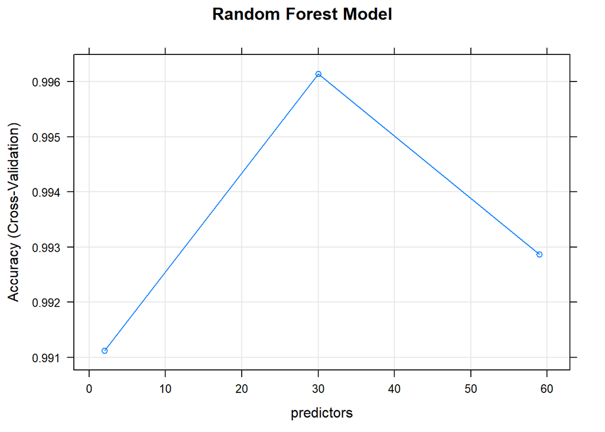

```r
modRf   <- train(classe ~ ., method="rf", trControl=trainControl(method="cv", number=4), data=training)
plot(modRf, xlab="predictors", main="Random Forest Model")
```

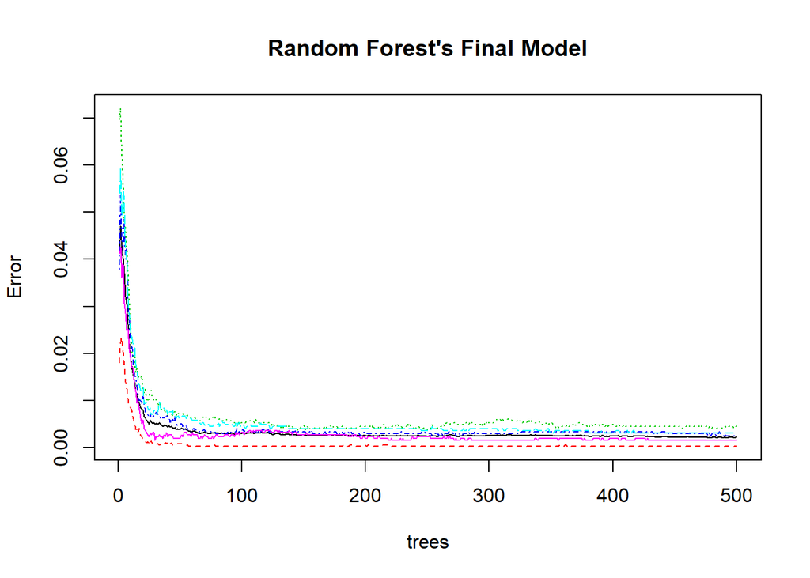

```r
plot(modRf$finalModel, main="Random Forest's Final Model")
```

```r
predRf  <- predict(modRf, testing)
summary(predRf)
```

```
##    A    B    C    D    E
## 1675 1139 1031  961 1079
```

```r
# Accuracy:
accuracy      <- modRf$results[3,2]

# Out Of Sample Error:
ooSampleError <- 1 - accuracy

data.frame(accuracy=accuracy, OutSampleError=ooSampleError)
```

```
##   accuracy OutSampleError
## 1 0.992866     0.00713405
```

## Testing the Model with 20 use cases

Once trained, the model was tested with the following test cases (pml-testing.csv) with the following results:

```
##  [1] B A B A A E D B A A B C B A E E A B B B
## Levels: A B C D E
```

Confirming the accuracy, all were the expected values.

## Conclusion

Random Forest model predicted 100% of the test cases, thought it is time consuming